# Using the grade penalty function

In this tutorial we explore the `gradePenaltyFn` by attempting to build roads to randomly selected locations in a mountainous region of British Columbia, Canada. While the elevation and landcover data used is real, the roads and landings are not and projected roads are not expected to match observed roads. In most real applications, an established existing road network will constrain the locations of new access roads. `gradePenaltyFn` uses a simplified version of the grade penalty approach taken by Anderson and Nelson (2004) to penalize roads that go up steep slopes and encourage roads to follow the contours of the landscape.

To use the grade penalty function we need to supply a raster to the `weightRaster` argument that contains elevation and has other barriers (eg water bodies) included in the raster as negative or `NA` values. In this example we will use an elevation and proportion water data set downloaded with the `geodata` package and cropped to an example area in British Columbia, Canada that is included in the package.

```r
library(roads)
library(terra)
library(dplyr)
library(sf)

# prep the terra rasters for use
dem_example <- prepExData(dem_example)
```

The elevation data shows that this is a mountainous region.

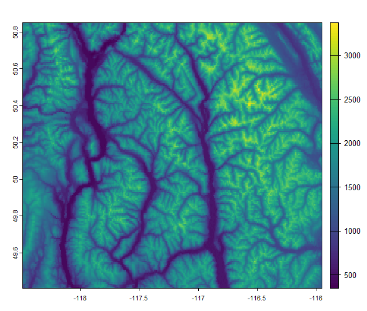

```r
plot(dem_example$ex_elev)
```

And the proportion of the landscape covered by water in each cell shows that there are several long narrow lakes crossing the landscape.

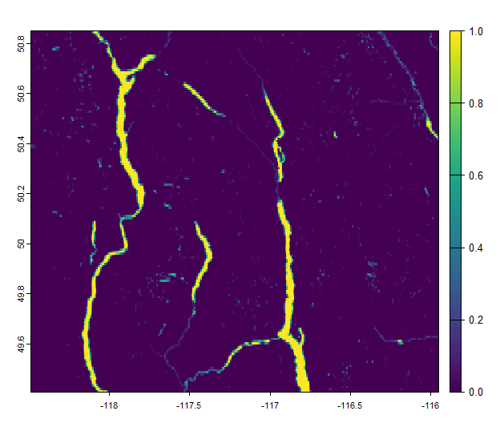

```r
plot(dem_example$ex_wat)
```

`gradePenaltyFn` requires a single raster as input but allows factors other than grade that will affect road construction to be included in the raster as negative values and barriers where no road construction is possible to be included as `NA` values. In this example we will assume that road construction is impossible for cells where the proportion of water is > 50%. Then we set areas with less than 1% water to NA so that the grade penalty will still apply in this case. We also need to get the penalty for water crossing on to a similar scale as the grade penalty in this case we will assume the same base cost of $16178 and the same penalty of $504 for every percentage point increase in percent water. Note this is just an example and there are certainly better data sources for the locations and costs of stream crossings.

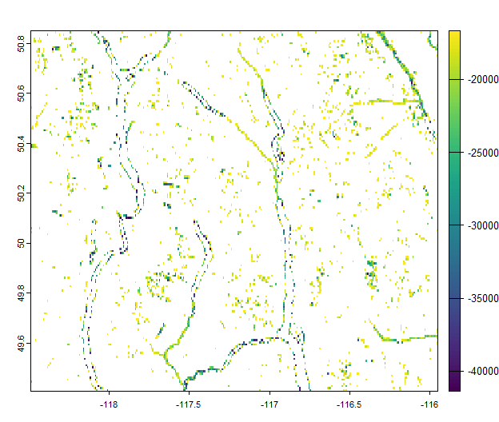

```r
# set water to NA when a cell is > 50% water
wat_use <- classify(dem_example$ex_wat, matrix(c(0.5, 1, NA), nrow = 1))

# set elev to NA when water is NA
elev_use <- mask(dem_example$ex_elev, wat_use)

# Now change water to NA when it is < 1% water
wat_use <- mask(wat_use, wat_use < 0.01, maskvalue = TRUE)

wat_use <- (wat_use *100) * -504 - 16178

plot(wat_use)
```

We then combine the two rasters together by setting elevation to 0 when there is a water penalty and summing them.

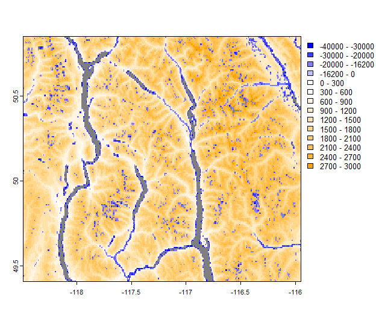

```r
# set elev to 0 when wat is NA
elev_use <- mask(elev_use, wat_use, inverse = TRUE, updatevalue = 0)

# add wat_use to elev when not NA
wt_rast <- sum(elev_use, wat_use, na.rm = TRUE)

par(mar = c(0,0,0,0.25))

plot(wt_rast, breaks = c(-40000, -30000, -20000, -16178, 0, 1:10*300, NA),
     col = c(terra::map.pal("blues", 5) %>% rev(), terra::map.pal("oranges", 10)),
     colNA = "grey50", mar = c(2, 2, 2, 6.5))
```

Next we randomly select points to serve as landings (i.e. locations to build roads to). We limit the landings to being at less than 2000m elevation and less than 1% water and then randomly select points. We use a stratified sample below since this is the easiest way to get a sample of just the cells that are `TRUE` in `for_area`

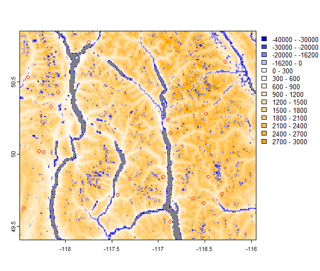

```r
# Get landing points

for_area <- is.na(wat_use) & !is.na(elev_use) & elev_use < 2000

names(for_area) <- "forest"

# set seed to make repeatable
set.seed(1235)

lnds <- spatSample(for_area, 20, method = "stratified", as.points = TRUE,
                   ext = ext(for_area)-0.001) %>%
  st_as_sf() %>%
  filter(forest == 1) %>%
  mutate(id = 1:n())

plot(wt_rast, breaks = c(-40000, -30000, -20000, -16178, 0, 1:10*300),
     col = c(terra::map.pal("blues", 5) %>% rev(), terra::map.pal("oranges", 10)),
     colNA = "grey50", mar = c(2, 2, 2, 6.5))

plot(lnds, add = TRUE, col = "red")
```

Finally, we create an initial road to serve as a starting point. This can be done interactively using `terra::draw` but we saved the result using `dput` to make it re-runnable.

```r
# Get starting road

# create line interactively
# line <- draw("line")
#
# line <- st_as_sf(line)

# get line non-interactively
rd_in <- structure(list(
  geometry = structure(list(
    structure(c(-118.103238840217, -118.103238840217, -118.112765313949, -118.115940805193,
                -118.115940805193, -118.106414331461, -118.106414331461, -118.100063348973,
                -118.077834910265, -118.074659419021,
                49.5276240233455, 49.5785159559446, 49.6090511155041,
                49.6355149204556, 49.6945495622705, 49.6965852395745,
                49.7108349807022, 49.7637625906053, 49.780048009037,
                49.8614751011955),
              dim = c(10L, 2L),
              class = c("XY", "LINESTRING", "sfg"))),
    n_empty = 0L, class = c("sfc_LINESTRING", "sfc"),
    precision = 0,
    bbox = structure(c(xmin = -118.115940805193,
                       ymin = 49.5276240233455,
                       xmax = -118.074659419021,
                       ymax = 49.8614751011955), class = "bbox"),
    crs = structure(list(input = NA_character_, wkt = NA_character_),
                    class = "crs"))),
  row.names = 1L, sf_column = "geometry",
  agr = structure(integer(0), class = "factor",
                  levels = c("constant", "aggregate","identity"),
                  names = character(0)), class = c("sf", "data.frame")) %>%
  st_set_crs(st_crs(lnds))
```

Now we are ready to project the locations of roads connecting each landing to our initial road network.

```r
rd_proj <- projectRoads(lnds, wt_rast, rd_in, weightFunction = gradePenaltyFn,
                        roadsInWeight = FALSE, roadMethod = "ilcp")
```

```
#> Burning in roads to weightRaster from sf
#> Warning in igraph::shortest_paths(sim$g, path.list[1], path.list[2], out =
#> "both"): At vendor/cigraph/src/paths/dijkstra.c:534 : Couldn't reach some
#> vertices.
#> Error: NA values in weightRaster along paths. Check for disconnected clumps in weightRaster. If weightFunction=gradePenaltyFn, try adjusting limit or setting limitWeight to high value that is not NA.
```

Our first attempt results in an error because one or more landings cannot be reached without traversing a grade of more than 20% which is the default value of `limit` in `gradePenaltyFn()`. To avoid this we can increase `limit` or change `limitWeight` to something other than `NA`. Below we try both setting `limit = 30` and `limitWeight = 40000^2`. Which have slightly different results.

```r
rd_proj <- projectRoads(lnds, wt_rast, rd_in, weightFunction = gradePenaltyFn,
                        roadsInWeight = FALSE, roadMethod = "ilcp", limit = 30)
```

```
#> Burning in roads to weightRaster from sf
```

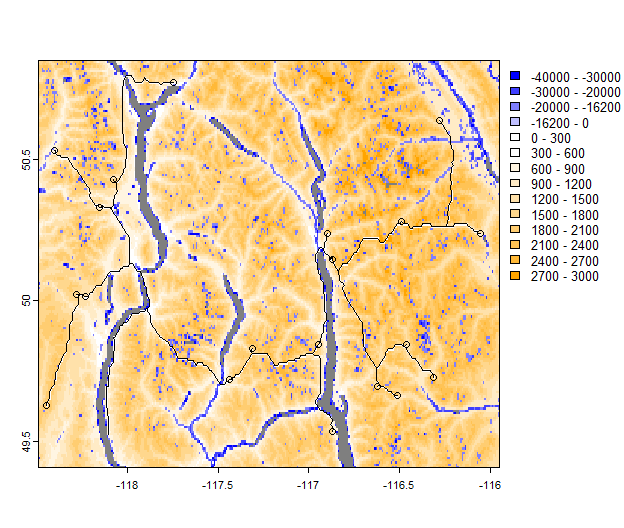

```r
plotRoads(rd_proj, breaks = c(-40000, -30000, -20000, -16178, 0, 1:10*300),
     col = c(terra::map.pal("blues", 5) %>% rev(), terra::map.pal("oranges", 10)),
     colNA = "grey50", mar = c(2, 2, 2, 6.5))
```

```r
rd_proj3 <- projectRoads(lnds, wt_rast, rd_in, weightFunction = gradePenaltyFn,
                        roadsInWeight = FALSE, roadMethod = "ilcp", limitWeight = 40000^2)
```

```
#> Burning in roads to weightRaster from sf
```

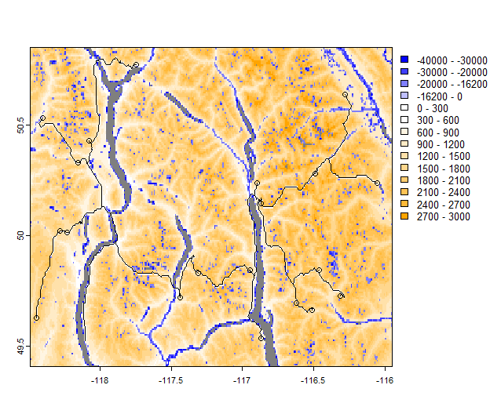

```r
plotRoads(rd_proj3, breaks = c(-40000, -30000, -20000, -16178, 0, 1:10*300),
     col = c(terra::map.pal("blues", 5) %>% rev(), terra::map.pal("oranges", 10)),
     colNA = "grey50", mar = c(2, 2, 2, 6.5))
```

Another challenge can occur if an area is not accessible without crossing cells that are `NA`. Below we set all areas with greater than 10% water to `NA`.

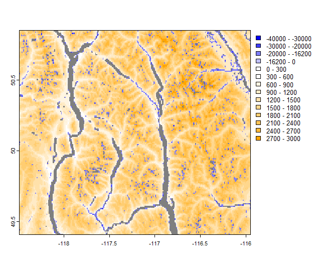

```r
# set > 10% water to NA
wat_10 <- classify(dem_example$ex_wat, matrix(c(0.1, 1, NA), nrow = 1))

wt_rast <- mask(wt_rast, wat_10)

plot(wt_rast, breaks = c(-40000, -30000, -20000, -16178, 0, 1:10*300),
     col = c(terra::map.pal("blues", 5) %>% rev(), terra::map.pal("oranges", 10)),
     colNA = "grey50", mar = c(2, 2, 2, 6.5))
```

```r
projectRoads(lnds, wt_rast, rd_in, weightFunction = gradePenaltyFn,
             roadsInWeight = FALSE, roadMethod = "ilcp", limit = 30)
```

```
#> Burning in roads to weightRaster from sf
#> Warning in igraph::shortest_paths(sim$g, path.list[1], path.list[2], out =
#> "both"): At vendor/cigraph/src/paths/dijkstra.c:534 : Couldn't reach some
#> vertices.
```

To address this we can change `NA` values to an arbitrarily large negative value to prevent crossing unless required.

```r
wt_rast <- subst(wt_rast, from = NA, to = -40000^2)

rd_proj2 <- projectRoads(lnds, wt_rast, rd_in, weightFunction = gradePenaltyFn,
             roadsInWeight = FALSE, roadMethod = "ilcp", limit = 30)
```

```
#> Burning in roads to weightRaster from sf
```

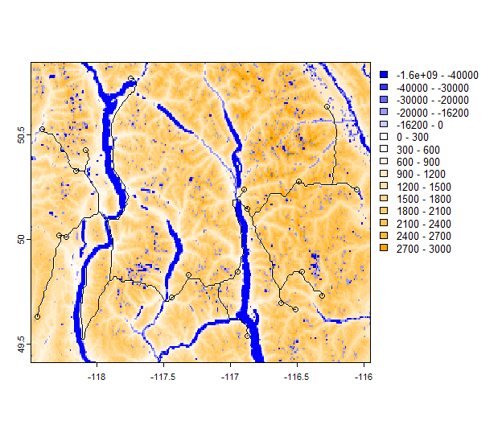

```r
plotRoads(rd_proj2, breaks = c(-40000^2, -40000, -30000, -20000, -16178, 0, 1:10*300),
     col = c(terra::map.pal("blues", 6) %>% rev(), terra::map.pal("oranges", 10)),
     colNA = "grey50", mar = c(2, 2, 2, 8.5))
```

## References

Anderson AE, Nelson J (2004) Projecting vector-based road networks with a shortest path algorithm. Canadian Journal of Forest Research 34:1444–1457. https://doi.org/10.1139/x04-030